# Full CFA/SEM workflow

Rémi Thériault

August 29, 2022

## CFA example

```r
# Load library
library(lavaan)
library(lavaanExtra)
library(tibble)

# Define latent variables
latent <- list(visual = paste0("x", 1:3),
               textual = paste0("x", 4:6),
               speed = paste0("x", 7:9))

# Write the model, and check it
cfa.model <- write_lavaan(latent = latent)
cat(cfa.model)
```

```
## ##################################################
## # [-----Latent variables (measurement model)-----]
##
## visual =~ x1 + x2 + x3
## textual =~ x4 + x5 + x6
## speed =~ x7 + x8 + x9
```

```
## lavaan 0.6-12 ended normally after 35 iterations
##
##   Estimator                                         ML
##   Optimization method                           NLMINB
##   Number of model parameters                        21
##
##   Number of observations                           301
##
## Model Test User Model:
##                                               Standard      Robust
##   Test Statistic                                85.306      87.132
##   Degrees of freedom                                24          24
##   P-value (Chi-square)                           0.000       0.000
##   Scaling correction factor                                  0.979
##     Yuan-Bentler correction (Mplus variant)
##
## Model Test Baseline Model:
##
##   Test statistic                               918.852     880.082
##   Degrees of freedom                                36          36
##   P-value                                        0.000       0.000
##   Scaling correction factor                                  1.044
##
## User Model versus Baseline Model:
##
##   Comparative Fit Index (CFI)                    0.931       0.925
##   Tucker-Lewis Index (TLI)                       0.896       0.888
##
##   Robust Comparative Fit Index (CFI)                         0.930
##   Robust Tucker-Lewis Index (TLI)                            0.895
##
## Loglikelihood and Information Criteria:
##
##   Loglikelihood user model (H0)              -3737.745   -3737.745
##   Scaling correction factor                                  1.133
##       for the MLR correction
##   Loglikelihood unrestricted model (H1)      -3695.092   -3695.092
##   Scaling correction factor                                  1.051
##       for the MLR correction
##
```

[output cut: 59 more lines]

```
##     visual            0.809    0.180    4.486    0.000    1.000    1.000
##     textual           0.979    0.121    8.075    0.000    1.000    1.000
##     speed             0.384    0.107    3.596    0.000    1.000    1.000
##
## R-Square:
##                    Estimate
##     x1                0.596
##     x2                0.179
##     x3                0.338
##     x4                0.725
##     x5                0.731
##     x6                0.702
##     x7                0.324
##     x8                0.523
##     x9                0.442
```

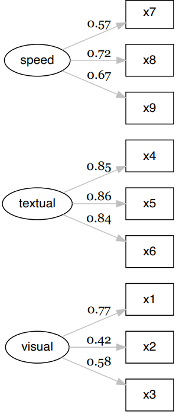

```r
# Fit the model fit and plot with `lavaanExtra::cfa_fit_plot`
# to get the factor loadings visually (optionally as PDF)
fit.cfa <- cfa_fit_plot(cfa.model, HolzingerSwineford1939)
```

```r
# Get fit indices
nice_fit(fit.cfa)
```

```
##     Model   chi2 df chi2.df p   CFI   TLI RMSEA  SRMR     AIC      BIC
## 1 Model 1 85.306 24   3.554 0 0.931 0.896 0.092 0.065 7517.49 7595.339
```

```r
# We can get it prettier with the `rempsyc::nice_table` integration
nice_fit(fit.cfa, nice_table = TRUE)
```

| Model | χ2 | df | χ2∕df | p | CFI | TLI | RMSEA | SRMR | AIC | BIC |
| --- | --- | --- | --- | --- | --- | --- | --- | --- | --- | --- |
| Model 1 | 85.31 | 24 | 3.55 | < .001 | 0.93 | 0.90 | 0.09 | 0.06 | 7,517.49 | 7,595.34 |
| Ideal Valuea | — | — | < 2 or 3 | > .05 | ≥ .95 | ≥ .95 | < .06-.08 | ≤ .08 | Smaller is better | Smaller is better |

aAs proposed by Schreiber et al. (2006).

But let’s say you had a bad fit and wanted to remove the three items with the lowest loadings, you can do so without have to respecify the model, only what items you wish to remove:

```
## lavaan 0.6-12 ended normally after 29 iterations
##
##   Estimator                                         ML
##   Optimization method                           NLMINB
##   Number of model parameters                        14
##
##   Number of observations                           301
##
## Model Test User Model:
##                                               Standard      Robust
##   Test Statistic                                 8.442       7.313
##   Degrees of freedom                                 7           7
##   P-value (Chi-square)                           0.295       0.397
##   Scaling correction factor                                  1.154
##     Yuan-Bentler correction (Mplus variant)
##
## Model Test Baseline Model:
##
##   Test statistic                               674.095     599.025
##   Degrees of freedom                                15          15
##   P-value                                        0.000       0.000
##   Scaling correction factor                                  1.125
##
## User Model versus Baseline Model:
##
##   Comparative Fit Index (CFI)                    0.998       0.999
##   Tucker-Lewis Index (TLI)                       0.995       0.999
##
##   Robust Comparative Fit Index (CFI)                         0.999
##   Robust Tucker-Lewis Index (TLI)                            0.999
##
## Loglikelihood and Information Criteria:
##
##   Loglikelihood user model (H0)              -2429.864   -2429.864
##   Scaling correction factor                                  1.137
##       for the MLR correction
##   Loglikelihood unrestricted model (H1)      -2425.644   -2425.644
##   Scaling correction factor                                  1.143
##       for the MLR correction
##
```

[output cut: 50 more lines]

```
##    .x6                0.362    0.047    7.689    0.000    0.362    0.302
##    .x8                0.756    0.090    8.407    0.000    0.756    0.740
##    .x9                0.228    0.167    1.359    0.174    0.228    0.224
##     visual            1.358    0.120   11.367    0.000    1.000    1.000
##     textual           0.981    0.121    8.093    0.000    1.000    1.000
##     speed             0.266    0.082    3.248    0.001    1.000    1.000
##
## R-Square:
##                    Estimate
##     x1                1.000
##     x4                0.726
##     x5                0.734
##     x6                0.698
##     x8                0.260
##     x9                0.776
```

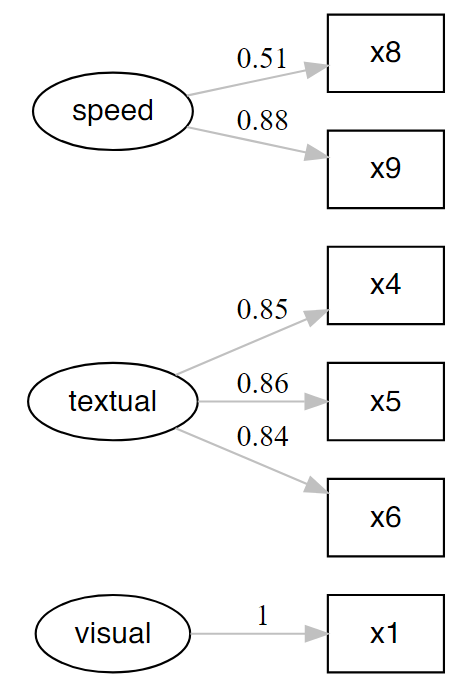

```r
# Fit the model fit and plot with `lavaanExtra::cfa_fit_plot`
# to get the factor loadings visually (as PDF)
fit.cfa2 <- cfa_fit_plot(cfa.model, HolzingerSwineford1939,
                         remove.items = paste0("x", c(2:3, 7)))
```

Let’s compare the fit to see if it’s better now:

```r
nice_fit(lst(fit.cfa, fit.cfa2), nice_table = TRUE)
```

| Model | χ2 | df | χ2∕df | p | CFI | TLI | RMSEA | SRMR | AIC | BIC |
| --- | --- | --- | --- | --- | --- | --- | --- | --- | --- | --- |
| fit.cfa | 85.31 | 24 | 3.55 | < .001 | 0.93 | 0.90 | 0.09 | 0.06 | 7,517.49 | 7,595.34 |
| fit.cfa2 | 8.44 | 7 | 1.21 | .295 | 1.00 | 0.99 | 0.03 | 0.02 | 4,887.73 | 4,939.63 |
| Ideal Valuea | — | — | < 2 or 3 | > .05 | ≥ .95 | ≥ .95 | < .06-.08 | ≤ .08 | Smaller is better | Smaller is better |

aAs proposed by Schreiber et al. (2006).

It is! If you like this table, you may also wish to save it to Word. Also easy:

```r
# Save fit table as an object
fit_table <- nice_fit(lst(fit.cfa, fit.cfa2), nice_table = TRUE)

# Save fit table to Word!
flextable::save_as_docx(fit_table, path = "fit_table.docx")
```

## SEM example

Here is a structural equation model example. We start with a path analysis first.

### Saturated model

One might decide to look at the saturated `lavaan` model first.

```r
# Calculate scale averages
data <- HolzingerSwineford1939
data$visual <- rowMeans(data[paste0("x", 1:3)])
data$textual <- rowMeans(data[paste0("x", 4:6)])
data$speed <- rowMeans(data[paste0("x", 7:9)])

# Define our variables
M <- "visual"
IV <- c("ageyr", "grade")
DV <- c("speed", "textual")

# Define our lavaan lists
mediation <- list(speed = M, textual = M, visual = IV)
regression <- list(speed = IV, textual = IV)
covariance <- list(speed = "textual", ageyr = "grade")

# Write the model, and check it
model.saturated <- write_lavaan(mediation, regression, covariance)
cat(model.saturated)
```

```
## ##################################################
## # [-----------Mediations (named paths)-----------]
##
## speed ~ visual
## textual ~ visual
## visual ~ ageyr + grade
##
## ##################################################
## # [---------Regressions (Direct effects)---------]
##
## speed ~ ageyr + grade
## textual ~ ageyr + grade
##
## ##################################################
## # [------------------Covariances-----------------]
##
## speed ~~ textual
## ageyr ~~ grade
```

This looks good so far, but we might also want to check our indirect effects (mediations). For this, we have to obtain the path names by setting `label = TRUE`. This will allow us to define our indirect effects and feed them back to `write_lavaan`.

```r
# We can run the model again.
# However, we set `label = TRUE` to get the path names
model.saturated <- write_lavaan(mediation, regression, covariance, label = TRUE)
cat(model.saturated)
```

```
## ##################################################
## # [-----------Mediations (named paths)-----------]
##
## speed ~ visual_speed*visual
## textual ~ visual_textual*visual
## visual ~ ageyr_visual*ageyr + grade_visual*grade
##
## ##################################################
## # [---------Regressions (Direct effects)---------]
##
## speed ~ ageyr + grade
## textual ~ ageyr + grade
##
## ##################################################
## # [------------------Covariances-----------------]
##
## speed ~~ textual
## ageyr ~~ grade
```

Here, if we check the mediation section of the model, we see that it has been “augmented” with the path names. Those are `visual_speed`, `visual_textual`, `ageyr_visual`, and `grade_visual`. The logic for the determination of the path names is predictable: it is always the predictor variable, on the left, followed by the predicted variable, on the right. So if we were to test all possible indirect effects, we would define our `indirect` object as such:

```r
# Define indirect object
indirect <- list(ageyr_visual_speed = c("ageyr_visual", "visual_speed"),
                 ageyr_visual_textual = c("ageyr_visual", "visual_textual"),
                 grade_visual_speed = c("grade_visual", "visual_speed"),
                 grade_visual_textual = c("grade_visual", "visual_textual"))

# Write the model, and check it
model.saturated <- write_lavaan(mediation, regression, covariance,
                                indirect, label = TRUE)
cat(model.saturated)
```

```
## ##################################################
## # [-----------Mediations (named paths)-----------]
##
## speed ~ visual_speed*visual
## textual ~ visual_textual*visual
## visual ~ ageyr_visual*ageyr + grade_visual*grade
##
## ##################################################
## # [---------Regressions (Direct effects)---------]
##
## speed ~ ageyr + grade
## textual ~ ageyr + grade
##
## ##################################################
## # [------------------Covariances-----------------]
##
## speed ~~ textual
## ageyr ~~ grade
##
## ##################################################
## # [--------Mediations (indirect effects)---------]
##
## ageyr_visual_speed := ageyr_visual * visual_speed
## ageyr_visual_textual := ageyr_visual * visual_textual
## grade_visual_speed := grade_visual * visual_speed
## grade_visual_textual := grade_visual * visual_textual
```

If preferred (e.g., when dealing with long variable names), one can choose to use letters for the predictor variables. Note however that this tends to be somewhat more confusing and ambiguous.

```r
# Write the model, and check it
model.saturated <- write_lavaan(mediation, regression, covariance,
                                label = TRUE, use.letters = TRUE)
cat(model.saturated)
```

```
## ##################################################
## # [-----------Mediations (named paths)-----------]
##
## speed ~ a_speed*visual
## textual ~ a_textual*visual
## visual ~ a_visual*ageyr + b_visual*grade
##
## ##################################################
## # [---------Regressions (Direct effects)---------]
##
## speed ~ ageyr + grade
## textual ~ ageyr + grade
##
## ##################################################
## # [------------------Covariances-----------------]
##
## speed ~~ textual
## ageyr ~~ grade
```

In this case, the path names are `a_speed`, `a_textual`, `a_visual`, and `b_visual`. So we would define our `indirect` object as such:

```r
# Define indirect object
indirect <- list(ageyr_visual_speed = c("a_visual", "a_speed"),
                 ageyr_visual_textual = c("a_visual", "a_textual"),
                 grade_visual_speed = c("b_visual", "a_speed"),
                 grade_visual_textual = c("b_visual", "a_textual"))

# Write the model, and check it
model.saturated <- write_lavaan(mediation, regression, covariance,
                                indirect, label = TRUE, use.letters = TRUE)
cat(model.saturated)
```

```
## ##################################################
## # [-----------Mediations (named paths)-----------]
##
## speed ~ a_speed*visual
## textual ~ a_textual*visual
## visual ~ a_visual*ageyr + b_visual*grade
##
## ##################################################
## # [---------Regressions (Direct effects)---------]
##
## speed ~ ageyr + grade
## textual ~ ageyr + grade
##
## ##################################################
## # [------------------Covariances-----------------]
##
## speed ~~ textual
## ageyr ~~ grade
##
## ##################################################
## # [--------Mediations (indirect effects)---------]
##
## ageyr_visual_speed := a_visual * a_speed
## ageyr_visual_textual := a_visual * a_textual
## grade_visual_speed := b_visual * a_speed
## grade_visual_textual := b_visual * a_textual
```

There is also an experimental feature that attempts to produce the indirect effects automatically. This feature requires specifying your independent, dependent, and mediator variables as “IV”, “M”, and “DV”, respectively, in the `indirect` object. In our case, we have already defined those earlier, so we can just feed the proper objects.

```r
# Define indirect object
indirect <- list(IV = IV, M = M, DV = DV)

# Write the model, and check it
model.saturated <- write_lavaan(mediation, regression, covariance,
                                indirect, label = TRUE)
cat(model.saturated)
```

```
## ##################################################
## # [-----------Mediations (named paths)-----------]
##
## speed ~ visual_speed*visual
## textual ~ visual_textual*visual
## visual ~ ageyr_visual*ageyr + grade_visual*grade
##
## ##################################################
## # [---------Regressions (Direct effects)---------]
##
## speed ~ ageyr + grade
## textual ~ ageyr + grade
##
## ##################################################
## # [------------------Covariances-----------------]
##
## speed ~~ textual
## ageyr ~~ grade
##
## ##################################################
## # [--------Mediations (indirect effects)---------]
##
## ageyr_visual_speed := ageyr_visual * visual_speed
## ageyr_visual_textual := ageyr_visual * visual_textual
## grade_visual_speed := grade_visual * visual_speed
## grade_visual_textual := grade_visual * visual_textual
```

We are now satisfied with our model, so we can finally fit it!

```r
# Fit the model with `lavaan`
fit.saturated <- sem(model.saturated, data = data)

# Get regression parameters only
# And make it pretty with the `rempsyc::nice_table` integration
lavaan_reg(fit.saturated, nice_table = TRUE, highlight = TRUE)
```

| Outcome | Predictor | β | p |
| --- | --- | --- | --- |
| speed | visual | 0.21 | < .001 |
| textual | visual | 0.24 | < .001 |
| visual | ageyr | -0.16 | .014 |
| visual | grade | 0.28 | < .001 |
| speed | ageyr | 0.04 | .568 |
| speed | grade | 0.31 | < .001 |
| textual | ageyr | -0.40 | < .001 |
| textual | grade | 0.36 | < .001 |

So `speed` as predicted by `ageyr` isn’t significant. We could remove that path from the model it if we are trying to make a more parsimonious model. Let’s make the non-saturated path analysis model next.

### Path analysis model

Because we use `lavaanExtra`, we don’t have to redefine the entire model: simply what we want to update. In this case, the regressions and the indirect effects.

```r
regression <- list(speed = "grade", textual = IV)

# We can run the model again, setting `label = TRUE` to get the path names
model.path <- write_lavaan(mediation, regression, covariance, label = TRUE)
cat(model.path)
```

```
## ##################################################
## # [-----------Mediations (named paths)-----------]
##
## speed ~ visual_speed*visual
## textual ~ visual_textual*visual
## visual ~ ageyr_visual*ageyr + grade_visual*grade
##
## ##################################################
## # [---------Regressions (Direct effects)---------]
##
## speed ~ grade
## textual ~ ageyr + grade
##
## ##################################################
## # [------------------Covariances-----------------]
##
## speed ~~ textual
## ageyr ~~ grade
```

```r
# We check that we have removed "ageyr" correctly from "speed" in the
# regression section. OK.

# Define just our indirect effects of interest
indirect <- list(age_visual_speed = c("ageyr_visual", "visual_speed"),
                 grade_visual_textual = c("grade_visual", "visual_textual"))

# We run the model again, with the indirect effects
model.path <- write_lavaan(mediation, regression, covariance,
                           indirect, label = TRUE)
cat(model.path)
```

```
## ##################################################
## # [-----------Mediations (named paths)-----------]
##
## speed ~ visual_speed*visual
## textual ~ visual_textual*visual
## visual ~ ageyr_visual*ageyr + grade_visual*grade
##
## ##################################################
## # [---------Regressions (Direct effects)---------]
##
## speed ~ grade
## textual ~ ageyr + grade
##
## ##################################################
## # [------------------Covariances-----------------]
##
## speed ~~ textual
## ageyr ~~ grade
##
## ##################################################
## # [--------Mediations (indirect effects)---------]
##
## age_visual_speed := ageyr_visual * visual_speed
## grade_visual_textual := grade_visual * visual_textual
```

```r
# Fit the model with `lavaan`
fit.path <- sem(model.path, data = data)

# Get regression parameters only
lavaan_reg(fit.path)
```

```
##   Outcome Predictor      B     p
## 1   speed    visual  0.206 0.000
## 2 textual    visual  0.235 0.000
## 3  visual     ageyr -0.161 0.014
## 4  visual     grade  0.281 0.000
## 5   speed     grade  0.327 0.000
## 6 textual     ageyr -0.403 0.000
## 7 textual     grade  0.358 0.000
```

```r
# We can get it prettier with the `rempsyc::nice_table` integration
lavaan_reg(fit.path, nice_table = TRUE, highlight = TRUE)
```

| Outcome | Predictor | β | p |
| --- | --- | --- | --- |
| speed | visual | 0.21 | < .001 |
| textual | visual | 0.24 | < .001 |
| visual | ageyr | -0.16 | .014 |
| visual | grade | 0.28 | < .001 |
| speed | grade | 0.33 | < .001 |
| textual | ageyr | -0.40 | < .001 |
| textual | grade | 0.36 | < .001 |

```r
# We only kept significant regressions. Good (for this demo).

# Get covariance indices
lavaan_cov(fit.path)
```

```
##    Variable.1 Variable.2     r     p
## 8       speed    textual 0.131 0.024
## 9       ageyr      grade 0.511 0.000
## 10      speed      speed 0.824 0.000
## 11    textual    textual 0.765 0.000
## 12     visual     visual 0.942 0.000
## 13      ageyr      ageyr 1.000 0.000
## 14      grade      grade 1.000 0.000
```

```r
# We can get it prettier with the `rempsyc::nice_table` integration
lavaan_cov(fit.path, nice_table = TRUE)
```

| Variable 1 | Variable 2 | r | p |
| --- | --- | --- | --- |
| speed | textual | .13 | .024 |
| ageyr | grade | .51 | < .001 |
| speed | speed | .82 | < .001 |
| textual | textual | .76 | < .001 |
| visual | visual | .94 | < .001 |
| ageyr | ageyr | 1.0 | < .001 |
| grade | grade | 1.0 | < .001 |

```r
# Get nice fit indices with the `rempsyc::nice_table` integration
nice_fit(lst(fit.cfa, fit.saturated, fit.path), nice_table = TRUE)
```

| Model | χ2 | df | χ2∕df | p | CFI | TLI | RMSEA | SRMR | AIC | BIC |
| --- | --- | --- | --- | --- | --- | --- | --- | --- | --- | --- |
| fit.cfa | 85.31 | 24 | 3.55 | < .001 | 0.93 | 0.90 | 0.09 | 0.06 | 7,517.49 | 7,595.34 |
| fit.saturated | 0.00 | 0 |  |  | 1.00 | 1.00 | 0.00 | 0.00 | 3,483.46 | 3,539.02 |
| fit.path | 0.33 | 1 | 0.33 | .568 | 1.00 | 1.03 | 0.00 | 0.01 | 3,481.79 | 3,533.64 |
| Ideal Valuea | — | — | < 2 or 3 | > .05 | ≥ .95 | ≥ .95 | < .06-.08 | ≤ .08 | Smaller is better | Smaller is better |

aAs proposed by Schreiber et al. (2006).

```r
# Let's get the indirect effects only
lavaan_ind(fit.path)
```

```
##             Indirect.Effect                       Paths      B     p
## 15     age → visual → speed   ageyr_visual*visual_speed -0.033 0.037
## 16 grade → visual → textual grade_visual*visual_textual  0.066 0.002
```

```r
# We can get it prettier with the `rempsyc::nice_table` integration
lavaan_ind(fit.path, nice_table = TRUE)
```

| Indirect Effect | Paths | β | p |
| --- | --- | --- | --- |
| age → visual → speed | ageyr_visual*visual_speed | -0.03 | .037 |
| grade → visual → textual | grade_visual*visual_textual | 0.07 | .002 |

```r
# Get modification indices only
modindices(fit.path, sort = TRUE, maximum.number = 5)
```

```
##       lhs op     rhs    mi    epc sepc.lv sepc.all sepc.nox
## 29 visual  ~ textual 0.326  1.622   1.622    1.975    1.975
## 35  grade  ~ textual 0.326 -0.228  -0.228   -0.488   -0.488
## 34  grade  ~   speed 0.326 -0.038  -0.038   -0.062   -0.062
## 19  speed ~~   grade 0.326 -0.021  -0.021   -0.056   -0.056
## 25  speed  ~ textual 0.326 -0.067  -0.067   -0.087   -0.087
```

For reference, this is our model, visually speaking

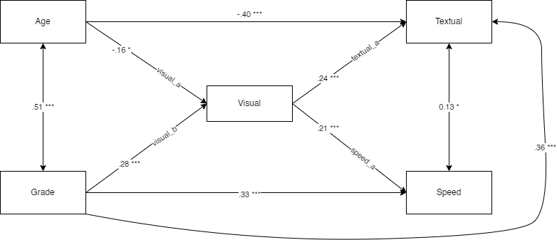

We could also attempt to draw it with `lavaanExtra::nice_tidySEM`, a convenience wrapper around the amazing `tidySEM` package.

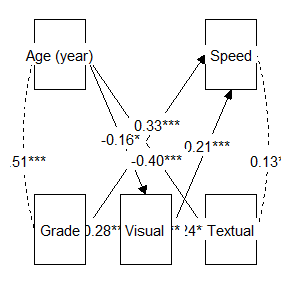

```r
labels <- list(ageyr = "Age (year)",
               grade = "Grade",
               visual = "Visual",
               speed = "Speed",
               textual = "Textual")
layout <- list(IV = IV, M = M, DV = DV)

nice_tidySEM(fit.path, layout = layout, label = labels,
             hide_nonsig_edges = TRUE, label_location = .60)
```

### Latent model

Finally, perhaps we change our mind and decide to run a full SEM instead, with latent variables. Fear not: we don’t have to redo everything again. We can simply define our latent variables and proceed. In this example, we have *already* defined our latent variable for our CFA earlier, so we don’t even need to write that again!

```r
model.latent <- write_lavaan(mediation, regression, covariance,
                             indirect, latent, label = TRUE)
cat(model.latent)
```

```
## ##################################################
## # [-----Latent variables (measurement model)-----]
##
## visual =~ x1 + x2 + x3
## textual =~ x4 + x5 + x6
## speed =~ x7 + x8 + x9
##
## ##################################################
## # [-----------Mediations (named paths)-----------]
##
## speed ~ visual_speed*visual
## textual ~ visual_textual*visual
## visual ~ ageyr_visual*ageyr + grade_visual*grade
##
## ##################################################
## # [---------Regressions (Direct effects)---------]
##
## speed ~ grade
## textual ~ ageyr + grade
##
## ##################################################
## # [------------------Covariances-----------------]
##
## speed ~~ textual
## ageyr ~~ grade
##
## ##################################################
## # [--------Mediations (indirect effects)---------]
##
## age_visual_speed := ageyr_visual * visual_speed
## grade_visual_textual := grade_visual * visual_textual
```

```r
# Run model
fit.latent <- sem(model.latent, data = HolzingerSwineford1939)

# Get nice fit indices with the `rempsyc::nice_table` integration
nice_fit(lst(fit.cfa, fit.saturated, fit.path, fit.latent), nice_table = TRUE)
```

| Model | χ2 | df | χ2∕df | p | CFI | TLI | RMSEA | SRMR | AIC | BIC |
| --- | --- | --- | --- | --- | --- | --- | --- | --- | --- | --- |
| fit.cfa | 85.31 | 24 | 3.55 | < .001 | 0.93 | 0.90 | 0.09 | 0.06 | 7,517.49 | 7,595.34 |
| fit.saturated | 0.00 | 0 |  |  | 1.00 | 1.00 | 0.00 | 0.00 | 3,483.46 | 3,539.02 |
| fit.path | 0.33 | 1 | 0.33 | .568 | 1.00 | 1.03 | 0.00 | 0.01 | 3,481.79 | 3,533.64 |
| fit.latent | 118.92 | 37 | 3.21 | < .001 | 0.92 | 0.89 | 0.09 | 0.06 | 8,638.79 | 8,746.20 |
| Ideal Valuea | — | — | < 2 or 3 | > .05 | ≥ .95 | ≥ .95 | < .06-.08 | ≤ .08 | Smaller is better | Smaller is better |

aAs proposed by Schreiber et al. (2006).